# Animal classification

This code is used to train a machine learning model able to classify 151 different species of animals and more than 16,000 images. The original dataset can be found here: [Animal Image Classification Dataset (kaggle.com)](https://www.kaggle.com/datasets/piyushkumar18/animal-image-classification-dataset)

## Import Python libraries

```python
import json
import os
import itertools
from PIL import Image
from sklearn.model_selection import train_test_split
from tensorflow.keras.preprocessing.image import ImageDataGenerator
from tensorflow.keras import layers, models
import pandas as pd
import matplotlib.pyplot as plt
from tensorflow.keras import regularizers
```

## Load class names and dataset

```python
# Path to your JSON file
file_path = 'class_names.json'

# Open the JSON file and load its content into a dictionary
with open(file_path, 'r') as file:
    class_names = json.load(file)['class_names']

# Print the resulting dictionary
print(class_names)
```

```
{'acinonyx-jubatus': 'Cheetah', 'aethia-cristatella': 'Crested Auklet', 'agalychnis-callidryas': 'Tree Frog', 'agkistrodon-contortrix': 'Eastern Copperhead', 'ailuropoda-melanoleuca': 'Giant Panda', 'ailurus-fulgens': 'Red Panda', 'alces-alces': 'Moose', 'anas-platyrhynchos': 'Mallard', 'ankylosauru…
```

```python
dataset_folder = 'dataset'

subfolders = [f.name for f in os.scandir(dataset_folder) if f.is_dir()]
n_classes = len(subfolders)

print(subfolders)
```

```
['acinonyx-jubatus', 'aethia-cristatella', 'agalychnis-callidryas', 'agkistrodon-contortrix', 'ailuropoda-melanoleuca', 'ailurus-fulgens', 'alces-alces', 'anas-platyrhynchos', 'ankylosaurus-magniventris', 'apis-mellifera', 'aptenodytes-forsteri', 'aquila-chrysaetos', 'ara-macao', 'architeuthis-dux',…
```

Splits the data into a training (80%) and a test (20%) dataset. The splitting is stratified, so each class is represented with the same proortion in the training and validation dataset (80-20).

```python
image_list = []
label_list = []

for subfolder in subfolders:
    file_list = os.listdir(os.path.join(dataset_folder,subfolder))
    image_list.append(['./' + subfolder + '/' + file for file in file_list])
    label_list.append([subfolder]*len(file_list))

image_list = list(itertools.chain(*image_list))
label_list = list(itertools.chain(*label_list))

x_train, x_test,y_train,y_test = train_test_split(image_list,label_list,test_size=0.2,stratify=label_list,random_state=0)


df_train = pd.DataFrame({'id' : x_train,'label' : y_train})
df_test = pd.DataFrame({'id' : x_test,'label' : y_test})

df_test.head()
```

|  | id | label |
| --- | --- | --- |
| 0 | ./ailuropoda-melanoleuca/panda_00355.jpg | ailuropoda-melanoleuca |
| 1 | ./crotalus-atrox/crotalus-atrox_52_1ad7f14d.jpg | crotalus-atrox |
| 2 | ./gallus-gallus-domesticus/A2ZWEWK3GO3B.jpg | gallus-gallus-domesticus |
| 3 | ./ailuropoda-melanoleuca/panda_00971.jpg | ailuropoda-melanoleuca |
| 4 | ./felis-catus/cats_00517.jpg | felis-catus |

## Preprocessing the training and validation datasets

The training and validation dataset are resized to 256x256 pixels. In addition, the training dataset is augmented by performing rotations and zooming.

```python
# Data augmentation and normalization for training
train_datagen = ImageDataGenerator(
    rescale=1./255,
    rotation_range=40,
    width_shift_range=0.2,
    height_shift_range=0.2,
    shear_range=0.2,
    zoom_range=0.2,
    horizontal_flip=True,
    fill_mode='nearest'
)

# flow_from_dataframe
# Only rescaling for validation
validation_datagen = ImageDataGenerator(rescale=1./255)
```

```python
# Flow training images in batches of 20 using train_datagen generator
train_generator = train_datagen.flow_from_dataframe(df_train,
                                                    directory = dataset_folder,
                                                    x_col="id", y_col="label",
                                                    target_size=(256, 256),
                                                    batch_size=100,
                                                    class_mode="categorical",
                                                    subset='training',
                                                    shuffle=True,
                                                    seed=42)
```

```
Found 16489 validated image filenames belonging to 151 classes.
```

```python
# Flow validation images in batches of 20 using validation_datagen generator
validation_generator = validation_datagen.flow_from_dataframe(
    df_test,
    directory = dataset_folder,
    x_col="id", y_col="label",
    target_size=(256, 256),
    batch_size=10,
    class_mode='categorical'
)
```

```
Found 4124 validated image filenames belonging to 151 classes.
```

## Builds the CNN model and performs the fitting

The CNN model comprises 5 convolution/max pooling layers, 2 hidden neural layers and the output layer. The output layer will return a vector of n_class probabilities.

```python
# Building the CNN model
model = models.Sequential([
    layers.Conv2D(32, (3, 3), activation='relu', input_shape=(256, 256, 3)),
    layers.MaxPooling2D((2, 2)),
    layers.Conv2D(64, (3, 3), activation='relu'),
    layers.MaxPooling2D((2, 2)),
    layers.Conv2D(128, (3, 3), activation='relu'),
    layers.MaxPooling2D((2, 2)),
    layers.Conv2D(128, (3, 3), activation='relu'),
    layers.MaxPooling2D((2, 2)),
    layers.Conv2D(128, (3, 3), activation='relu'),
    layers.MaxPooling2D((2, 2)),
    layers.Flatten(),
    layers.Dense(1024, activation='relu', kernel_regularizer=regularizers.l2(0.001)),
    layers.Dropout(0.2),
    layers.Dense(1024, activation='relu', kernel_regularizer=regularizers.l2(0.001)),
    layers.Dropout(0.2),
    layers.Dense(n_classes, activation='softmax')
])

# Compiling the model
model.compile(loss='categorical_crossentropy',
              optimizer='adam',
              metrics=['accuracy'])

# Training the model
history = model.fit(
    train_generator,
    epochs=100,
    validation_data=validation_generator
)

# Evaluating the model
test_loss, test_acc = model.evaluate(validation_generator)
print(f"Test accuracy: {test_acc}")
```

```
165/165 ━━━━━━━━━━━━━━━━━━━━ 799s 5s/step - accuracy: 0.0805 - loss: 5.3469 - val_accuracy: 0.1062 - val_loss: 4.1596
165/165 ━━━━━━━━━━━━━━━━━━━━ 710s 4s/step - accuracy: 0.1212 - loss: 4.0962 - val_accuracy: 0.1576 - val_loss: 3.8884
165/165 ━━━━━━━━━━━━━━━━━━━━ 722s 4s/step - accuracy: 0.1570 - loss: 3.8391 - val_accuracy: 0.2241 - val_loss: 3.5104
165/165 ━━━━━━━━━━━━━━━━━━━━ 661s 4s/step - accuracy: 0.2172 - loss: 3.5594 - val_accuracy: 0.2798 - val_loss: 3.2743
165/165 ━━━━━━━━━━━━━━━━━━━━ 646s 4s/step - accuracy: 0.2636 - loss: 3.3033 - val_accuracy: 0.3024 - val_loss: 3.0935
165/165 ━━━━━━━━━━━━━━━━━━━━ 662s 4s/step - accuracy: 0.2910 - loss: 3.1495 - val_accuracy: 0.3276 - val_loss: 2.9741
165/165 ━━━━━━━━━━━━━━━━━━━━ 651s 4s/step - accuracy: 0.3054 - loss: 3.0472 - val_accuracy: 0.3138 - val_loss: 3.1403
165/165 ━━━━━━━━━━━━━━━━━━━━ 682s 4s/step - accuracy: 0.3376 - loss: 2.9228 - val_accuracy: 0.3768 - val_loss: 2.7678
165/165 ━━━━━━━━━━━━━━━━━━━━ 695s 4s/step - accuracy: 0.3555 - loss: 2.8332 - val_accuracy: 0.3523 - val_loss: 3.0377
165/165 ━━━━━━━━━━━━━━━━━━━━ 648s 4s/step - accuracy: 0.3755 - loss: 2.7674 - val_accuracy: 0.3926 - val_loss: 2.7079
165/165 ━━━━━━━━━━━━━━━━━━━━ 610s 4s/step - accuracy: 0.3714 - loss: 2.7598 - val_accuracy: 0.4028 - val_loss: 2.6879
165/165 ━━━━━━━━━━━━━━━━━━━━ 608s 4s/step - accuracy: 0.3924 - loss: 2.6402 - val_accuracy: 0.4149 - val_loss: 2.5663
165/165 ━━━━━━━━━━━━━━━━━━━━ 683s 4s/step - accuracy: 0.4120 - loss: 2.5829 - val_accuracy: 0.4185 - val_loss: 2.6788
165/165 ━━━━━━━━━━━━━━━━━━━━ 674s 4s/step - accuracy: 0.4204 - loss: 2.5504 - val_accuracy: 0.4030 - val_loss: 2.6906
165/165 ━━━━━━━━━━━━━━━━━━━━ 604s 4s/step - accuracy: 0.4194 - loss: 2.5209 - val_accuracy: 0.4522 - val_loss: 2.4786
165/165 ━━━━━━━━━━━━━━━━━━━━ 638s 4s/step - accuracy: 0.4393 - loss: 2.4255 - val_accuracy: 0.4467 - val_loss: 2.5142
165/165 ━━━━━━━━━━━━━━━━━━━━ 657s 4s/step - accuracy: 0.4530 - loss: 2.3869 - val_accuracy: 0.4401 - val_loss: 2.5454
165/165 ━━━━━━━━━━━━━━━━━━━━ 642s 4s/step - accuracy: 0.4649 - loss: 2.3448 - val_accuracy: 0.4673 - val_loss: 2.4372
165/165 ━━━━━━━━━━━━━━━━━━━━ 656s 4s/step - accuracy: 0.4734 - loss: 2.2863 - val_accuracy: 0.4297 - val_loss: 2.6095
165/165 ━━━━━━━━━━━━━━━━━━━━ 628s 4s/step - accuracy: 0.4818 - loss: 2.2659 - val_accuracy: 0.4845 - val_loss: 2.3124
165/165 ━━━━━━━━━━━━━━━━━━━━ 629s 4s/step - accuracy: 0.4865 - loss: 2.2495 - val_accuracy: 0.4661 - val_loss: 2.4761
165/165 ━━━━━━━━━━━━━━━━━━━━ 615s 4s/step - accuracy: 0.4933 - loss: 2.2320 - val_accuracy: 0.4760 - val_loss: 2.4930
165/165 ━━━━━━━━━━━━━━━━━━━━ 612s 4s/step - accuracy: 0.4971 - loss: 2.2154 - val_accuracy: 0.4476 - val_loss: 2.5819
165/165 ━━━━━━━━━━━━━━━━━━━━ 595s 4s/step - accuracy: 0.5038 - loss: 2.1801 - val_accuracy: 0.4966 - val_loss: 2.3022
165/165 ━━━━━━━━━━━━━━━━━━━━ 632s 4s/step - accuracy: 0.5243 - loss: 2.1040 - val_accuracy: 0.5201 - val_loss: 2.2298
165/165 ━━━━━━━━━━━━━━━━━━━━ 601s 4s/step - accuracy: 0.5203 - loss: 2.1239 - val_accuracy: 0.5029 - val_loss: 2.3689
165/165 ━━━━━━━━━━━━━━━━━━━━ 570s 3s/step - accuracy: 0.5247 - loss: 2.1062 - val_accuracy: 0.4956 - val_loss: 2.3700
165/165 ━━━━━━━━━━━━━━━━━━━━ 571s 3s/step - accuracy: 0.5319 - loss: 2.0799 - val_accuracy: 0.5630 - val_loss: 2.0786
165/165 ━━━━━━━━━━━━━━━━━━━━ 586s 3s/step - accuracy: 0.5460 - loss: 2.0296 - val_accuracy: 0.5150 - val_loss: 2.3381
165/165 ━━━━━━━━━━━━━━━━━━━━ 568s 3s/step - accuracy: 0.5512 - loss: 1.9976 - val_accuracy: 0.4964 - val_loss: 2.4960
165/165 ━━━━━━━━━━━━━━━━━━━━ 594s 4s/step - accuracy: 0.5494 - loss: 2.0019 - val_accuracy: 0.5456 - val_loss: 2.1321
165/165 ━━━━━━━━━━━━━━━━━━━━ 619s 4s/step - accuracy: 0.5562 - loss: 2.0027 - val_accuracy: 0.5609 - val_loss: 2.1028
165/165 ━━━━━━━━━━━━━━━━━━━━ 613s 4s/step - accuracy: 0.5719 - loss: 1.9262 - val_accuracy: 0.5172 - val_loss: 2.3117
165/165 ━━━━━━━━━━━━━━━━━━━━ 590s 4s/step - accuracy: 0.5666 - loss: 1.9278 - val_accuracy: 0.5577 - val_loss: 2.1044
165/165 ━━━━━━━━━━━━━━━━━━━━ 597s 4s/step - accuracy: 0.5718 - loss: 1.9147 - val_accuracy: 0.5235 - val_loss: 2.2318
165/165 ━━━━━━━━━━━━━━━━━━━━ 587s 3s/step - accuracy: 0.5688 - loss: 1.9177 - val_accuracy: 0.5473 - val_loss: 2.1971
165/165 ━━━━━━━━━━━━━━━━━━━━ 609s 4s/step - accuracy: 0.5920 - loss: 1.8476 - val_accuracy: 0.5795 - val_loss: 2.0621
165/165 ━━━━━━━━━━━━━━━━━━━━ 614s 4s/step - accuracy: 0.5835 - loss: 1.8719 - val_accuracy: 0.5308 - val_loss: 2.2892
165/165 ━━━━━━━━━━━━━━━━━━━━ 641s 4s/step - accuracy: 0.5835 - loss: 1.8705 - val_accuracy: 0.5485 - val_loss: 2.2936
165/165 ━━━━━━━━━━━━━━━━━━━━ 610s 4s/step - accuracy: 0.5938 - loss: 1.8496 - val_accuracy: 0.5829 - val_loss: 2.0411
```

[output cut: 47 more lines]

```
165/165 ━━━━━━━━━━━━━━━━━━━━ 570s 3s/step - accuracy: 0.6963 - loss: 1.4728 - val_accuracy: 0.6115 - val_loss: 2.0505
165/165 ━━━━━━━━━━━━━━━━━━━━ 591s 4s/step - accuracy: 0.6905 - loss: 1.4737 - val_accuracy: 0.6275 - val_loss: 1.9819
165/165 ━━━━━━━━━━━━━━━━━━━━ 597s 4s/step - accuracy: 0.6931 - loss: 1.4830 - val_accuracy: 0.6203 - val_loss: 2.0820
165/165 ━━━━━━━━━━━━━━━━━━━━ 594s 4s/step - accuracy: 0.6864 - loss: 1.4978 - val_accuracy: 0.5948 - val_loss: 2.2204
165/165 ━━━━━━━━━━━━━━━━━━━━ 622s 4s/step - accuracy: 0.6984 - loss: 1.4726 - val_accuracy: 0.6215 - val_loss: 2.0780
165/165 ━━━━━━━━━━━━━━━━━━━━ 583s 3s/step - accuracy: 0.6985 - loss: 1.4831 - val_accuracy: 0.6358 - val_loss: 2.0499
165/165 ━━━━━━━━━━━━━━━━━━━━ 593s 3s/step - accuracy: 0.6969 - loss: 1.4630 - val_accuracy: 0.6389 - val_loss: 1.9631
165/165 ━━━━━━━━━━━━━━━━━━━━ 611s 4s/step - accuracy: 0.6953 - loss: 1.4707 - val_accuracy: 0.6329 - val_loss: 2.0076
165/165 ━━━━━━━━━━━━━━━━━━━━ 595s 4s/step - accuracy: 0.7059 - loss: 1.4491 - val_accuracy: 0.6237 - val_loss: 2.0056
165/165 ━━━━━━━━━━━━━━━━━━━━ 586s 3s/step - accuracy: 0.7030 - loss: 1.4354 - val_accuracy: 0.6431 - val_loss: 1.9356
165/165 ━━━━━━━━━━━━━━━━━━━━ 614s 4s/step - accuracy: 0.7060 - loss: 1.4468 - val_accuracy: 0.6324 - val_loss: 2.0545
165/165 ━━━━━━━━━━━━━━━━━━━━ 574s 3s/step - accuracy: 0.7066 - loss: 1.4193 - val_accuracy: 0.6642 - val_loss: 1.9104
165/165 ━━━━━━━━━━━━━━━━━━━━ 570s 3s/step - accuracy: 0.7165 - loss: 1.4013 - val_accuracy: 0.6266 - val_loss: 2.0838
413/413 ━━━━━━━━━━━━━━━━━━━━ 39s 95ms/step - accuracy: 0.6334 - loss: 2.0558
Test accuracy: 0.6265761256217957
```

```python
# Saving the model
model.save('pet_classifier_model.h5')
model.save('pet_classifier_model.keras')
```

```
WARNING:absl:You are saving your model as an HDF5 file via `model.save()` or `keras.saving.save_model(model)`. This file format is considered legacy. We recommend using instead the native Keras format, e.g. `model.save('my_model.keras')` or `keras.saving.save_model(model, 'my_model.keras')`.
```

## Evaluating the model accuracy

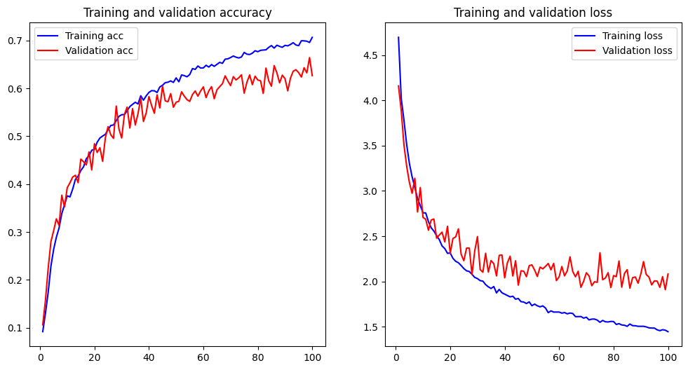

```python
# Plotting training and validation accuracy
acc = history.history['accuracy']
val_acc = history.history['val_accuracy']
loss = history.history['loss']
val_loss = history.history['val_loss']

epochs = range(1, len(acc) + 1)

plt.figure(figsize=(12, 6))

plt.subplot(1, 2, 1)
plt.plot(epochs, acc, 'b', label='Training acc')
plt.plot(epochs, val_acc, 'r', label='Validation acc')
plt.title('Training and validation accuracy')
plt.legend()

plt.subplot(1, 2, 2)
plt.plot(epochs, loss, 'b', label='Training loss')
plt.plot(epochs, val_loss, 'r', label='Validation loss')
plt.title('Training and validation loss')
plt.legend()
```

The plot shows that the expected accuracy should be around 60%. However, the accuracy is much higher for the training dataset than the validation dataset, suggesting that this model tends to overfit the training data. A next step regarding the model would be to reduce the overfitting, e.g. by including more regularization or changing the hidden layers.